# MRC Reef Assessment

Molly Wilson

11/29/2020

## Benthic

Notes on adjustments to OG benthic dataset:

- Consistency in use of spaces/dashes/underscores - currently species codes have identifier first, then underscore to indicator/additional data (e.g. switch ND CCA to CCA_ND, TA FB to TA_FB, etc.) (done)
  - Eventually switch unknown MA to something like RFMA_UK or RFMA_SPP, and switch other algal species to codes (e.g. Dictyota) for easier entry. Doesn’t matter for this version
- Some extra lookups can be removed, e.g. PDC - WP
- Jania should be capitalized (done)
- Making sure species names are capitalized properly (done in R code)
- Split urchins and recruits into separate sheets (done)

```r
# import and processing

benthic <- read_excel(here("data", "MRC_benthic_V5.xlsx"), sheet = "benthic") %>% clean_names() %>%
  filter(!is.na(site)) %>%
  select(-c(date, surveyor, notes)) %>%
  separate(species_code, c("species_code", "indicator")) %>% # separating variables with an underscore into two columns
  mutate(species = to_any_case(species, case = "sentence"), # this makes sure species names are correctly capitalized
         site = to_any_case(site, case = "title"),
         benthic_class = case_when(category_code %in% c("LC", "SLC") ~ "Hard corals",
                                  category_code %in% c("MA") ~ "Macroalgae",
                                  category_code %in% c("TA") ~ "Turf algae",
                                  category_code %in% c("CCA", "CCA_ND") ~ "CCA",
                                  category_code %in% c("OINV", "SPON", "AINV", "CYAN", "PEY") ~ "Other competitors",
                                  category_code %in% c("SAND", "HOLE", "SG", "PAVE") ~ "Other substratum"
                                    ),
         algal_type = case_when(type_code %in% c("BFMA", "GFMA", "RFMA") ~ "Fleshy macroalgae",
                                type_code %in% c("GCMA", "RCMA") ~ "Calcareous macroalgae",
                                type_code %in% c("TA", "TAS", "STA") ~ "Turf algae"),
         av_sub_yn = if_else(category_code %in% c("SAND", "HOLE", "SG", "PAVE"), "no", "yes")
         )  %>%
  filter(!(site %in% c("Rickett's Bay", "Rickett s Bay") & ((transect == 1 & meter == 9) | (transect == 2 & meter == 9)))) # both of these meters were only sand and/or seagrass, and were causing issues later in the analysis

# "expand" a dataframe so that it contains all benthic classes per site/transect/meter, and then join the full dataset so that any meters where a species was absent it will show up as 0 (as opposed to just not having an entry at all)
benthic.pc.class.m <- benthic %>%
  filter(av_sub_yn == "yes") %>%
  expand(nesting(site, transect, meter), benthic_class) %>%
  # this is where we add in our actual data to this expanded template:
  left_join(benthic %>%
              filter(av_sub_yn == "yes") %>% # only looking at what is considered available substrate (no sand, etc.)
              group_by(site, transect, meter) %>%
              mutate(n_pts = n()) %>% # showing total number of points per meter that are considered available substrate
              ungroup() %>%
              group_by(site, transect, meter, n_pts, benthic_class) %>%
              summarize(pc.m = 100*n()/n_pts) %>% # n() counts the number of entries within a given group
              ungroup() %>%
              distinct() %>%
              select(-n_pts),
            by = c("site", "transect", "meter", "benthic_class")) %>%
  mutate(pc.m = if_else(is.na(pc.m), 0, pc.m))

# average these meter-level results within transect, then within sites
benthic.pc.class <- benthic.pc.class.m %>%
  group_by(site, transect, benthic_class) %>%
  summarize(pc.t = mean(pc.m)) %>%
  ungroup() %>%
  group_by(site, benthic_class) %>%
  summarize(n.test = n(),
            pc = mean(pc.t),
            se = sd(pc.t)/sqrt(n())
            ) %>%
  filter(benthic_class != "Other substratum") %>%
  mutate(benthic_class = factor(benthic_class, levels = c("Hard corals", "CCA", "Macroalgae", "Turf algae", "Other competitors")))

# quick check to make sure everything adds up to 100% at the meter and site level
test.m <- benthic.pc.class.m %>%
  group_by(site, transect, meter) %>%
  summarize(total = sum(pc.m))
test.site <- benthic.pc.class %>%
  group_by(site) %>%
  summarize(total = sum(pc))

# calculating percent cover by type and site

benthic.pc.type.m <- benthic %>%
  expand(nesting(site, transect, meter), nesting(type, type_code)) %>%
  left_join(benthic %>%
              filter(av_sub_yn == "yes") %>%
              group_by(site, transect, meter) %>%
              mutate(n_pts = n()) %>%
              ungroup() %>%
              group_by(site, transect, meter, n_pts, type, type_code) %>%
              summarize(pc.m = 100*n()/n_pts) %>%
              ungroup() %>%
              distinct() %>%
              select(-n_pts),
            by = c("site", "transect", "meter", "type", "type_code")) %>%
  mutate(pc.m = if_else(is.na(pc.m), 0, pc.m))

benthic.pc.type <- benthic.pc.type.m %>%
  group_by(site, transect, type, type_code) %>%
  summarize(pc.t = mean(pc.m)) %>%
  ungroup() %>%
  group_by(site, type, type_code) %>%
  summarize(pc = mean(pc.t),
            se = sd(pc.t)/sqrt(n())
            ) %>%
  ungroup() %>%
  left_join(benthic %>%
              select(type, benthic_class) %>%
              distinct(),
            by = "type") %>%
  filter(benthic_class != "Other substratum")

test.m <- benthic.pc.type.m %>%
  group_by(site, transect, meter) %>%
  summarize(total = sum(pc.m))
test.site <- benthic.pc.type %>%
  group_by(site) %>%
  summarize(total = sum(pc))

# calculating percent cover by species and site

benthic.pc.spp.m <- benthic %>%
  expand(nesting(site, transect, meter), species_code) %>%
  left_join(benthic %>%
              filter(av_sub_yn == "yes") %>%
              group_by(site, transect, meter) %>%
              mutate(n_pts = n()) %>%
              ungroup() %>%
              group_by(site, transect, meter, n_pts, species_code) %>%
              summarize(pc.m = 100*n()/n_pts) %>%
              ungroup() %>%
              distinct() %>%
              select(-n_pts),
            by = c("site", "transect", "meter", "species_code")) %>%
  mutate(pc.m = if_else(is.na(pc.m), 0, pc.m))

benthic.pc.spp <- benthic.pc.spp.m %>%
  group_by(site, transect, species_code) %>%
  summarize(pc.t = mean(pc.m)) %>%
  ungroup() %>%
  group_by(site, species_code) %>%
  summarize(pc = mean(pc.t),
            se = sd(pc.t)/sqrt(n())
            ) %>%
  ungroup() %>%
  left_join(benthic %>%
              select(species_code, benthic_class) %>%
              distinct(),
            by = "species_code") %>%
  filter(benthic_class != "Other substratum")

test.m <- benthic.pc.spp.m %>%
  group_by(site, transect, meter) %>%
  summarize(total = sum(pc.m))
test.site <- benthic.pc.spp %>%
  group_by(site) %>%
  summarize(total = sum(pc))
```

### Site-level summary

Notes:

- All scleractinian corals (LC, SLC) are grouped here as hard corals
- All AINV, OINV, SPON, CYAN, and PEY are grouped as other competitors
- These values are percent cover of available substrate (i.e. does not include seagrass, sand, holes, and pavement - wasn’t sure what to do with pavement or what that exactly is)
- Rickett’s Bay apostrophe comes out in actual graph file, not on this knit html for some reason

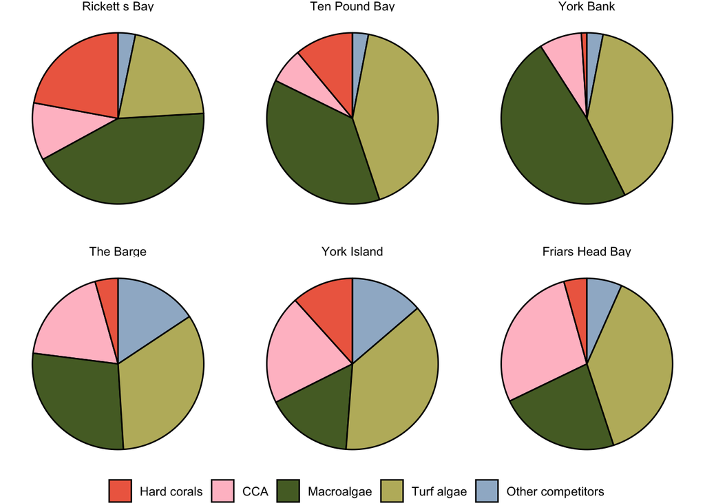

```r
class.palette <- c("coral2", "pink", "darkolivegreen", "darkkhaki", "slategray3")

ggplot(benthic.pc.class %>%
         mutate(site = factor(site, levels = c("Rickett s Bay", "Ten Pound Bay", "York Bank", "The Barge", "York Island", "Friars Head Bay"))),
       aes(x = "benthic_class", y = pc, fill = benthic_class)) +
  geom_bar(width = 1, stat = "identity", color = "black") +
  coord_polar("y", start=0) +
  scale_fill_manual(values = class.palette) +
  facet_wrap(vars(site), nrow = 2) +
  #geom_text(aes(y = ypos, label = pc), color = "white", size=2) +
  theme_void() +
  theme(legend.position = "bottom",
        legend.title = element_blank(),
        panel.spacing = unit(1, "lines"))
```

```r
ggsave(here("img", "benthic_pie.png"))
```

**Values for percent cover and standard error by benthic class:**

```r
kable(benthic.pc.class %>% select(site, benthic_class, pc, se))
```

| site | benthic_class | pc | se |
| --- | --- | --- | --- |
| Friars Head Bay | CCA | 27.818783 | 5.8120068 |
| Friars Head Bay | Hard corals | 4.333333 | 2.6034166 |
| Friars Head Bay | Macroalgae | 22.906085 | 2.1917558 |
| Friars Head Bay | Other competitors | 6.629630 | 3.7462373 |
| Friars Head Bay | Turf algae | 38.312169 | 10.5177602 |
| Rickett s Bay | CCA | 10.882936 | 2.3672536 |
| Rickett s Bay | Hard corals | 22.076940 | 10.4139716 |
| Rickett s Bay | Macroalgae | 42.978505 | 8.9442570 |
| Rickett s Bay | Other competitors | 3.257937 | 1.6656601 |
| Rickett s Bay | Turf algae | 20.803682 | 6.8783555 |
| Ten Pound Bay | CCA | 6.694444 | 2.9152554 |
| Ten Pound Bay | Hard corals | 11.034722 | 4.3663476 |
| Ten Pound Bay | Macroalgae | 37.387897 | 10.2632871 |
| Ten Pound Bay | Other competitors | 3.000000 | 1.2773751 |
| Ten Pound Bay | Turf algae | 41.882936 | 4.7200799 |
| The Barge | CCA | 18.666667 | 5.3644923 |
| The Barge | Hard corals | 4.333333 | 1.8559215 |
| The Barge | Macroalgae | 28.000000 | 1.5275252 |
| The Barge | Other competitors | 15.666667 | 2.3333333 |
| The Barge | Turf algae | 33.333333 | 2.0275875 |
| York Bank | CCA | 8.037037 | 0.6097066 |
| York Bank | Hard corals | 1.037037 | 0.5785370 |
| York Bank | Macroalgae | 48.259259 | 1.8102740 |
| York Bank | Other competitors | 3.037037 | 0.6097066 |
| York Bank | Turf algae | 39.629630 | 2.9899236 |
| York Island | CCA | 20.736111 | 2.7514844 |
| York Island | Hard corals | 11.662698 | 4.1675679 |
| York Island | Macroalgae | 16.401786 | 5.0631939 |
| York Island | Other competitors | 13.718254 | 2.9953909 |
| York Island | Turf algae | 37.481151 | 4.1977248 |

### Hard corals

Notes:

- It gets complicated to include disease instances in here because of the error bars. It could be better just to note that the only disease observed on transects was on OFAV in Ten Pound Bay…?
- If you would prefer to arrange these by genus and not by abundance that is easy!

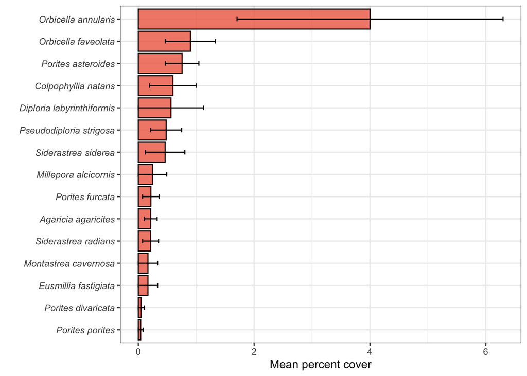

```r
corals <- benthic.pc.spp %>%
  filter(benthic_class %in% c("Hard corals")) %>%
  select(-benthic_class) %>%
  group_by(species_code) %>%
  summarize(pc.tot = mean(pc),
            se = sd(pc)/sqrt(n())) %>%
  left_join(benthic %>%
              filter(category_code %in% c("LC", "SLC")) %>%
              select(species_code, species, genus = type) %>%
              distinct())

ggplot(corals, aes(x = reorder(species, pc.tot), y = pc.tot)) +
  geom_col(color = "black", fill = "coral2", alpha = 0.8, stat = "identity",
           position = position_dodge()) +
  geom_errorbar(aes(ymin = pc.tot - se, ymax = pc.tot + se), width = .2,
                 position = position_dodge(.9)) +
  coord_flip() +
  labs(x = "", y = "Mean percent cover") +
  theme_bw() +
  theme(axis.text.y = element_text(face = "italic"))
```

```r
ggsave(here("img", "coral_spp.png"))
```

```r
# Coral stress by species and site

coral.stress.spp <- benthic %>%
  filter(benthic_class %in% c("Live hard corals", "Stressed hard corals")) %>%
  mutate(health = case_when(is.na(indicator) ~ "Healthy",
                             indicator == "PD" ~ "Partially dead",
                             indicator == "D" ~ "Diseased"
                           )) %>%
  group_by(species) %>%
  mutate(n.obs = n()) %>%
  ungroup() %>%
  group_by(species, health) %>%
  summarize(n = n(),
            p = n/n.obs) %>%
  distinct()

ggplot(coral.stress.spp, aes(x = species, y = n, fill = health)) +
  geom_col(color = "black") +
  coord_flip() +
  scale_fill_manual(values = c("gray30", "cadetblue", "gray90"), name = "Health") +
  labs(x = "Coral species", y = "Number of points observed") +
  theme_bw()

coral.stress.site <- benthic %>%
  filter(benthic_class %in% c("Live hard corals", "Stressed hard corals")) %>%
  mutate(health = case_when(is.na(indicator) ~ "Healthy",
                             indicator == "PD" ~ "Partially dead",
                             indicator == "D" ~ "Diseased"
                           )) %>%
  group_by(site) %>%
  mutate(n.obs = n()) %>%
  ungroup() %>%
  group_by(site, health) %>%
  summarize(n = n(),
            p = n/n.obs) %>%
  distinct()

ggplot(coral.stress.site, aes(x = site, y = n, fill = health)) +
  geom_col(color = "black") +
  coord_flip() +
  scale_fill_manual(values = c("gray30", "cadetblue", "gray90"), name = "Health") +
  labs(x = "Site", y = "Number of points observed") +
  theme_bw()
```

### Algae

Notes:

- Not sure if we wanted to include turf and macroalgae here, but could be good to look at in terms of overall palatability…?
- Might be better to take out the colors and just add the x axis text back in…?

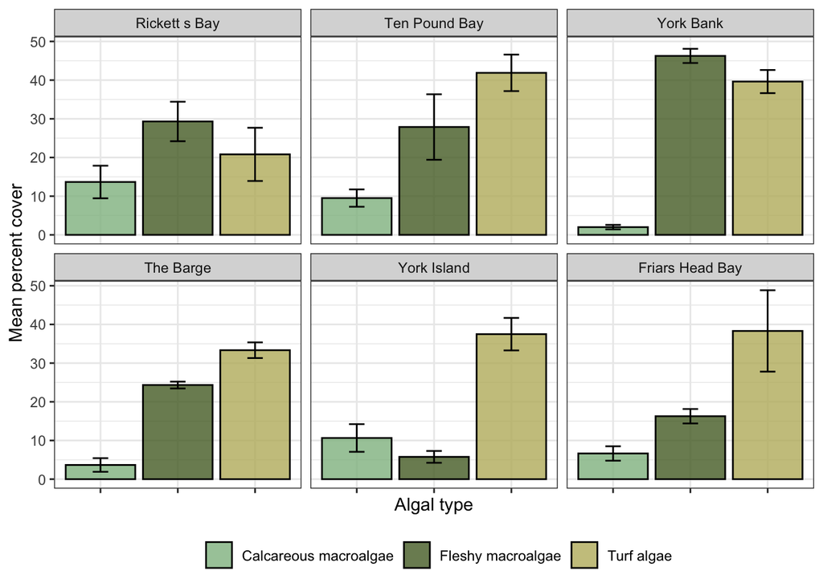

```r
algae.pc.type.m <- benthic %>%
  expand(nesting(site, transect, meter), algal_type) %>%
  left_join(benthic %>%
              filter(av_sub_yn == "yes") %>%
              group_by(site, transect, meter) %>%
              mutate(n_pts = n()) %>%
              ungroup() %>%
              group_by(site, transect, meter, n_pts, algal_type) %>%
              summarize(pc.m = 100*n()/n_pts) %>%
              ungroup() %>%
              distinct() %>%
              select(-n_pts),
            by = c("site", "transect", "meter", "algal_type")) %>%
  mutate(pc.m = if_else(is.na(pc.m), 0, pc.m))

algae.pc.type <- algae.pc.type.m %>%
  group_by(site, transect, algal_type) %>%
  summarize(pc.t = mean(pc.m)) %>%
  ungroup() %>%
  group_by(site, algal_type) %>%
  summarize(pc = mean(pc.t),
            se = sd(pc.t)/sqrt(n())
            ) %>%
  ungroup()

test.m <- algae.pc.type.m %>%
  group_by(site, transect, meter) %>%
  summarize(total = sum(pc.m))
test.site <- algae.pc.type %>%
  group_by(site) %>%
  summarize(total = sum(pc))

algal.palette <- c("darkseagreen", "darkolivegreen", "darkkhaki")
ggplot(algae.pc.type %>%
         filter(!is.na(algal_type)) %>%
         mutate(site = factor(site, levels = c("Rickett s Bay", "Ten Pound Bay", "York Bank", "The Barge", "York Island", "Friars Head Bay"))),
       aes(x = algal_type, y = pc, fill = algal_type)) +
  geom_col(stat = "identity", color = "black", alpha = 0.8,
           position = position_dodge()) +
  geom_errorbar(aes(ymin = pc - se, ymax = pc + se), width = .2,
                 position = position_dodge(.9)) +
  scale_fill_manual(values = algal.palette) +
  facet_wrap(vars(site), nrow = 2) +
  labs(x = "Algal type", y = "Mean percent cover") +
  theme_bw() +
  theme(axis.text.x = element_blank(),
        legend.position = "bottom",
        legend.title = element_blank())
```

```r
ggsave(here("img", "algae.png"))
```

```r
kable(algae.pc.type)
```

| site | algal_type | pc | se |
| --- | --- | --- | --- |
| Friars Head Bay | Calcareous macroalgae | 6.638889 | 1.8580683 |
| Friars Head Bay | Fleshy macroalgae | 16.267196 | 1.8642086 |
| Friars Head Bay | Turf algae | 38.312169 | 10.5177602 |
| Friars Head Bay | NA | 38.781746 | 8.7247566 |
| Rickett s Bay | Calcareous macroalgae | 13.666005 | 4.2108641 |
| Rickett s Bay | Fleshy macroalgae | 29.312500 | 5.1067558 |
| Rickett s Bay | Turf algae | 20.803682 | 6.8783555 |
| Rickett s Bay | NA | 36.217813 | 10.3847156 |
| Ten Pound Bay | Calcareous macroalgae | 9.506944 | 2.2396991 |
| Ten Pound Bay | Fleshy macroalgae | 27.880952 | 8.4649086 |
| Ten Pound Bay | Turf algae | 41.882936 | 4.7200799 |
| Ten Pound Bay | NA | 20.729167 | 6.2897949 |
| The Barge | Calcareous macroalgae | 3.666667 | 1.7638342 |
| The Barge | Fleshy macroalgae | 24.333333 | 0.8819171 |
| The Barge | Turf algae | 33.333333 | 2.0275875 |
| The Barge | NA | 38.666667 | 2.1858128 |
| York Bank | Calcareous macroalgae | 2.000000 | 0.5773503 |
| York Bank | Fleshy macroalgae | 46.259259 | 1.8306190 |
| York Bank | Turf algae | 39.629630 | 2.9899236 |
| York Bank | NA | 12.111111 | 1.2521586 |
| York Island | Calcareous macroalgae | 10.641865 | 3.5759621 |
| York Island | Fleshy macroalgae | 5.759921 | 1.5315211 |
| York Island | Turf algae | 37.481151 | 4.1977248 |
| York Island | NA | 46.117064 | 5.0153656 |

```r
###  Sedimentation

# Notes:
#
#   - These are calculated as the percent of all turf points that are TA/TAS/STA, and do not reflect the percent cover of all turf algal types within a site

sediment.m <- benthic %>%
  filter(category_code == "TA") %>%
  expand(nesting(site, transect, meter), type_code) %>%
  left_join(benthic %>%
              filter(category_code == "TA") %>%
              group_by(site, transect, meter) %>%
              mutate(n_pts = n()) %>%
              ungroup() %>%
              group_by(site, transect, meter, n_pts, type_code) %>%
              summarize(pc.m = 100*n()/n_pts) %>%
              ungroup() %>%
              distinct() %>%
              select(-n_pts),
            by = c("site", "transect", "meter", "type_code")) %>%
  mutate(pc.m = if_else(is.na(pc.m), 0, pc.m))

sediment <- sediment.m %>%
  group_by(site, transect, type_code) %>%
  summarize(pc.t = mean(pc.m)) %>%
  ungroup() %>%
  group_by(site, type_code) %>%
  summarize(pc = mean(pc.t),
            se = sd(pc.t)/sqrt(n())
            ) %>%
  ungroup() %>%
  mutate(sedimentation = case_when(type_code == "TA" ~ "Low",
                                  type_code == "TAS" ~ "Medium",
                                  type_code == "STA" ~ "High")) %>%
  mutate(sedimentation = factor(sedimentation, levels = c("Low", "Medium", "High")))

ggplot(sediment, aes(x = sedimentation, y = pc)) +
  geom_col(stat = "identity", color = "black", fill = "bisque3", alpha = 0.8,
           position = position_dodge()) +
  geom_errorbar(aes(ymin = pc - se, ymax = pc + se), width = .2,
                 position = position_dodge(.9)) +
  #scale_fill_manual(values = sediment.palette) +
  facet_wrap(vars(site), nrow = 2) +
  labs(x = "Sedimentation level", y = "Percent of turf algae") +
  theme_bw() +
  theme(#axis.text.x = element_blank(),
        legend.position = "bottom",
        legend.title = element_blank())
```

## Fish

```r
# import and processing

fish <- read_excel(here("data", "MRC_fish.xlsx"), sheet = "mrc.fish") %>% clean_names() %>%
  select(-c(date, time, depth_m, surveyor)) %>% # not using these variables currently, so nice to streamline
  filter(!is.na(site)) %>% # remove any incomplete rows at the end of the data
  uncount(number) %>% # expand to replicate rows if multiple fish were recorded
  mutate(phase_code = tolower(phase),
         phase = case_when(phase == "j" ~ "Juvenile",
                           phase == "i" ~ "Initial",
                           phase == "t" ~ "Terminal"))

# total biomass by site
fish.bm.site <- fish %>%
  filter(biomass > 0) %>%
  group_by(site, transect) %>%
  summarize(bm.t = sum(biomass/1000/120*10000)) %>% # kg/ha
  group_by(site) %>%
  summarize(bm = mean(bm.t),
            se = sd(bm.t)/sqrt(n()))

# species biomass by transect
fish.bm.spp.t.raw <- fish %>%
  filter(biomass > 0) %>%
  group_by(site, transect, species_code) %>%
  summarize(bm.spp.t = sum(biomass/1000/120*10000)) # kg/ha

fish.bm.spp.t <- fish %>%
  expand(site, transect, species_code) %>%
  left_join(fish.bm.spp.t.raw, by = c("site", "transect", "species_code")) %>%
  mutate(bm.spp.t = if_else(is.na(bm.spp.t), 0, bm.spp.t)) %>%
  left_join(fish %>%
              select(species_code, species_name, common_name, family, functional_group) %>%
              unique(),
                      by = "species_code")

# species biomass by site
fish.bm.spp.site <- fish.bm.spp.t %>%
  group_by(site, species_code, species_name, common_name, family, functional_group) %>%
  summarize(n.t = n(),
            bm = mean(bm.spp.t),
            se = sd(bm.spp.t)/sqrt(n.t))

# species biomass across sites
fish.bm.spp <- fish.bm.spp.site %>%
  group_by(species_code, species_name, common_name, family, functional_group) %>%
  summarize(bm.tot = mean(bm),
            se = sd(bm)/sqrt(n()))

# functional group biomass by site
fish.bm.func.site <- fish.bm.spp.t %>% # extra code - currently don't use this
  group_by(site, functional_group, transect) %>%
  summarize(bm.func.t = sum(bm.spp.t)) %>%
  ungroup() %>%
  group_by(site, functional_group) %>%
  summarize(n.t = n(),
            bm = mean(bm.func.t),
            se = sd(bm.func.t)/sqrt(n.t))

# family biomass by site
fish.bm.fam.site <- fish.bm.spp.t %>%
  group_by(site, family, transect) %>%
  summarize(bm.fam.t = sum(bm.spp.t)) %>%
  ungroup() %>%
  group_by(site, family) %>%
  summarize(n.t = n(),
            bm = mean(bm.fam.t),
            se = sd(bm.fam.t)/sqrt(n.t))
```

### Total biomass by site

Notes:

- Regional averages are taken from Karr et al. 2015

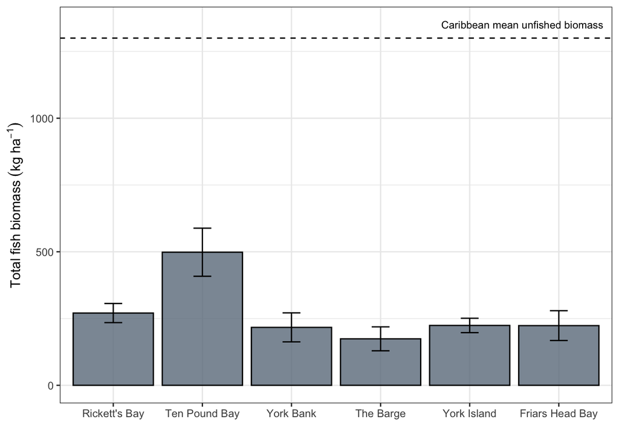

```r
ggplot(fish.bm.site %>%
         mutate(site = factor(site, levels = c("Rickett's Bay", "Ten Pound Bay", "York Bank", "The Barge", "York Island", "Friars Head Bay"))),
       aes(x = site, y = bm)) +
  geom_col(color = "black", fill = "slategray4", alpha = 0.8, stat = "identity", position = position_dodge()) +
  geom_errorbar(aes(ymin = bm - se, ymax = bm + se), width = .2,
                 position = position_dodge(.9)) +
  geom_hline(yintercept = 1300, linetype = "dashed", color = "black") +
  annotate("text", x = 6.5, y = 1350, size = 3, hjust = 1, label=c('Caribbean mean unfished biomass')) +
  labs(x = "", y = expression(Total~fish~biomass~(kg~ha^-1))) +
  theme_bw()
```

```r
ggsave(here("img", "fish_bm.png"))
```

```r
kable(fish.bm.site)
```

| site | bm | se |
| --- | --- | --- |
| Friars Head Bay | 223.4939 | 55.79177 |
| Rickett’s Bay | 270.5309 | 35.83262 |
| Ten Pound Bay | 498.3125 | 90.03089 |
| The Barge | 174.0385 | 44.80856 |
| York Bank | 216.9422 | 54.28476 |
| York Island | 224.1261 | 26.97997 |

### Parrotfish biomass by site

Notes:

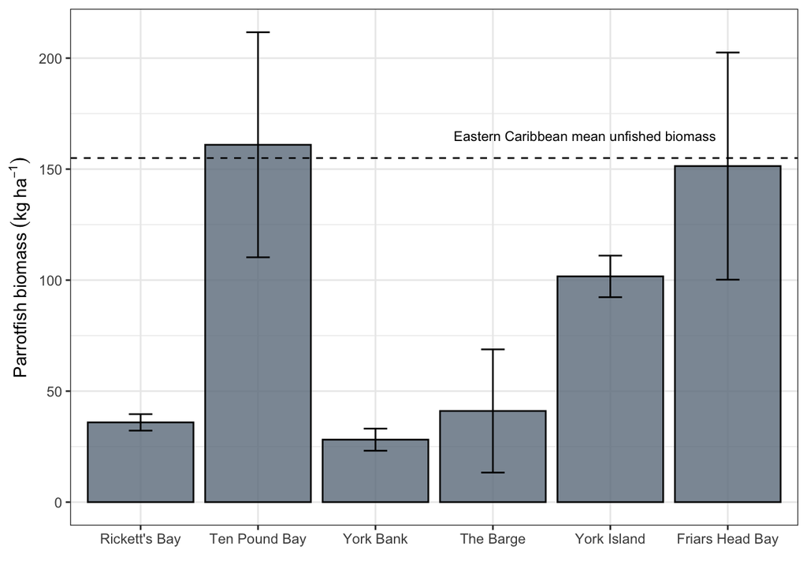

```r
ggplot(fish.bm.fam.site %>%
        filter(family == "Scaridae") %>%
         mutate(site = factor(site, levels = c("Rickett's Bay", "Ten Pound Bay", "York Bank", "The Barge", "York Island", "Friars Head Bay"))),
       aes(x = site, y = bm)) +
  geom_col(color = "black", fill = "slategray4", alpha = 0.8, stat = "identity", position = position_dodge()) +
  geom_errorbar(aes(ymin = bm - se, ymax = bm + se), width = .2,
                 position = position_dodge(.9)) +
  geom_hline(yintercept = 155, linetype = "dashed", color = "black") +
  annotate("text", x = 5.9, y = 165, size = 3, hjust = 1, label=c('Eastern Caribbean mean unfished biomass')) +
  labs(x = "", y = expression(Parrotfish~biomass~(kg~ha^-1))) +
  theme_bw()
```

```r
ggsave(here("img", "scarid_bm.png"))
```

```r
kable(fish.bm.fam.site %>% filter(family == "Scaridae"))
```

| site | family | n.t | bm | se |
| --- | --- | --- | --- | --- |
| Friars Head Bay | Scaridae | 5 | 151.37511 | 51.163231 |
| Rickett’s Bay | Scaridae | 5 | 35.92186 | 3.711580 |
| Ten Pound Bay | Scaridae | 5 | 160.96992 | 50.690049 |
| The Barge | Scaridae | 5 | 41.06132 | 27.749947 |
| York Bank | Scaridae | 5 | 28.13775 | 4.980041 |
| York Island | Scaridae | 5 | 101.68284 | 9.365147 |

Notes:

- Minimum sizes at maturity from O’Farrell et al. 2015:
  - Sp. viride, 18 cm (Winn and Bardach 1960);
  - Sp. aurofrenatum, 15 cm (Garcı´a-Cagide et al. 1994);
  - Sc. vetula, 19 cm (Winn and Bardach 1960);
  - and Sc. taeniopterus, 19 cm (Munro 1983).

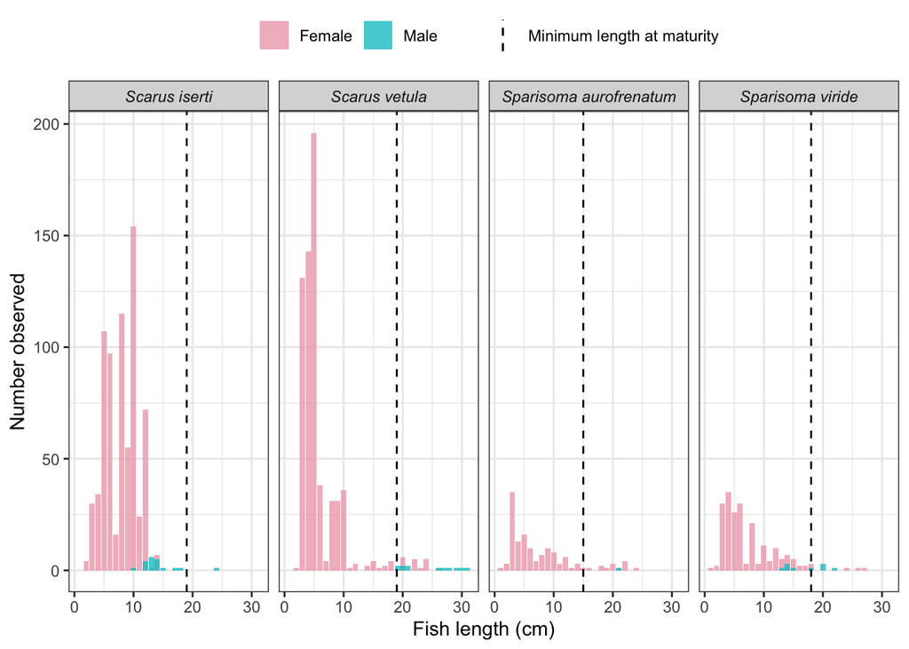

```r
scarids <- fish %>%
  filter(species_code %in% c("stop", "rbp", "qup", "strp") & !is.na(phase)) %>%
  mutate(sex = case_when(phase %in% c("Juvenile", "Initial") ~ "Female",
                         phase == "Terminal" ~ "Male"))

ggplot(scarids, aes(x = length, fill = sex)) +
  geom_histogram(stat = "count", alpha = 0.8, position = 'identity') +
  facet_wrap(vars(species_name), ncol = 4) +
  geom_vline(data = filter(scarids, species_code == "stop"), aes(xintercept = 18, color = "Minimum length at maturity"), linetype = "dashed") +
  geom_vline(data = filter(scarids, species_code == "qup"), aes(xintercept = 19, color = "Minimum length at maturity"), linetype = "dashed") +
  geom_vline(data = filter(scarids, species_code == "rbp"), aes(xintercept = 15, color = "Minimum length at maturity"), linetype = "dashed") +
  geom_vline(data = filter(scarids, species_code == "strp"), aes(xintercept = 19, color = "Minimum length at maturity"), linetype = "dashed") +
  scale_color_manual(values = c("black")) +
  scale_fill_manual(values=c("pink2", "turquoise3")) +
  theme_bw() +
  labs(x = "Fish length (cm)", y = "Number observed", fill="") +
  theme(strip.text = element_text(face = "italic"),
        legend.title = element_blank(),
        legend.position = "top")
```

```r
ggsave(here("img", "scarid_length.png"))
```

### Species biomass across sites

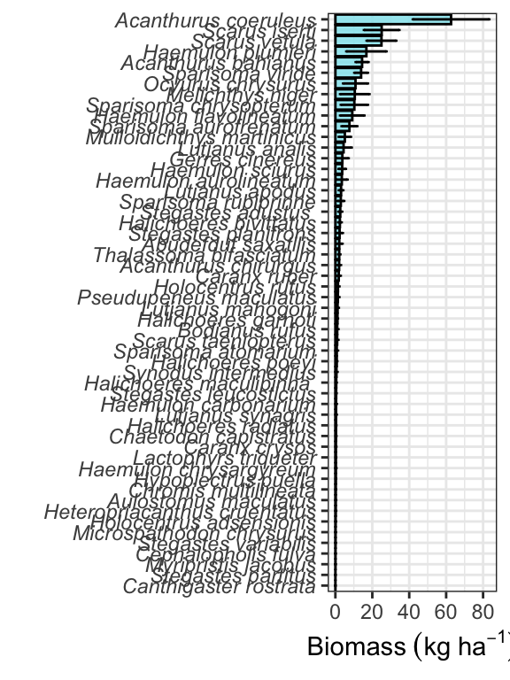

```r
ggplot(fish.bm.spp,
       aes(x = reorder(species_name, bm.tot), y = bm.tot)) +
  geom_col(color = "black", fill = "cadetblue2", alpha = 0.8, stat = "identity", position = position_dodge()) +
  geom_errorbar(aes(ymin = bm.tot - se, ymax = bm.tot + se), width = .2,
                 position = position_dodge(.9)) +
  coord_flip() +
  labs(y = expression(Biomass~(kg~ha^-1)), x = "") +
  theme_bw() +
  theme(axis.text.y = element_text(face = "italic"),
        legend.position = "right",
        legend.title = element_blank())
```

```r
ggsave(here("img", "fish_spp.png"))
```

## Diadema

Notes:

- Estimated pre-mortality estimates for Antigua are obtained from Jackson et al. 2014, Bauer 1980 ~ 5 indv./m$^2$

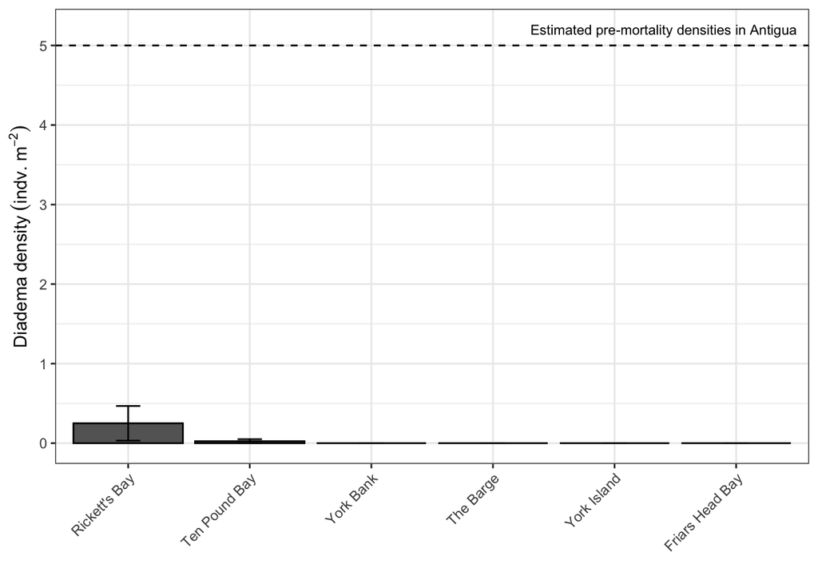

```r
diadema <- read_excel(here("data", "MRC_benthic_V5.xlsx"), sheet = "macroinvertebrates") %>% clean_names() %>%
  filter(!is.na(site)) %>%
  select(-c(date, surveyor)) %>%
  mutate(count = (diadema_adults + diadema_juvenile)/10) %>% # converting to #/m2 (from #/10m2)
  select(site, transect, count) %>%
  group_by(site) %>%
  summarize(density = mean(count),
            se = sd(count)/sqrt(n()))

ggplot(diadema %>%
         mutate(site = factor(site, levels = c("Rickett's Bay", "Ten Pound Bay", "York Bank", "The Barge", "York Island", "Friars Head Bay"))), aes(x = site, y = density)) +
  geom_col(stat = "identity", color = "black", fill = "gray20", alpha = 0.8,
           position = position_dodge()) +
  geom_errorbar(aes(ymin = density - se, ymax = density + se), width = .2,
                 position = position_dodge(.9)) +
  geom_hline(yintercept = 5, linetype = "dashed", color = "black") +
  annotate("text", x = 6.5, y = 5.2, size = 3, hjust = 1, label=c('Estimated pre-mortality densities in Antigua')) +
  #geom_text(aes(0, 5, label = "test", vjust = -1), size = 3) +
  theme_bw() +
  labs(y = expression(Diadema~density~(indv.~m^-2)), x = "") +
  theme(axis.text.x = element_text(angle = 45, hjust = 1))
```

```r
ggsave(here("img", "diadema.png"))
```

## Rugosity

Notes:

- From Alvarez-Filip et al. 2009: Lesser Antilles average was 2.1 in the 1970s, 1.5 in 2000s

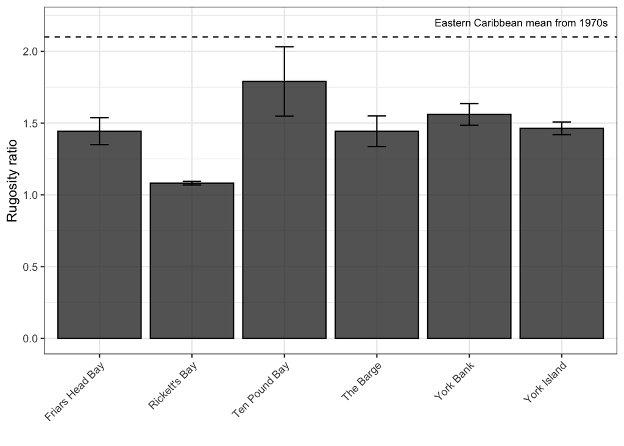

```r
rugosity <- read_excel(here("data", "mrc_fish.xlsx"), sheet = "mrc.rugosity") %>% clean_names() %>%
   select(-c(date, time, depth_m, surveyor))

rugosity <- rugosity %>%
  group_by(site, transect) %>%
  summarize(rugosity.t = mean(rugosity/100)) %>%
  group_by(site) %>%
  summarize(rugosity = mean(rugosity.t),
            se = sd(rugosity.t)/sqrt(n()))

ggplot(rugosity, aes(x = site, y = rugosity)) +
  geom_col(stat = "identity", color = "black", fill = "gray20", alpha = 0.8,
           position = position_dodge()) +
  geom_errorbar(aes(ymin = rugosity - se, ymax = rugosity + se), width = .2,
                 position = position_dodge(.9)) +
  geom_hline(yintercept = 2.1, linetype = "dashed", color = "black") +
  annotate("text", x = 6.5, y = 2.2, size = 3, hjust = 1, label=c('Eastern Caribbean mean from 1970s')) +
  theme_bw() +
  labs(y = "Rugosity ratio", x = "") +
  theme(axis.text.x = element_text(angle = 45, hjust = 1))
```

```r
ggsave(here("img", "rugosity.png"))
```